# HBO Game of Thrones Analysis

# Analysis on tweets with the hashtag #GameofThrones

# Data Collection

```python
import csv
import pandas as pd
import re
import json
```

```python
#Reading in our file
tweets = []
with open("C:\\Users\\Grant\\Desktop\\670\\5_Twitter_Analytics\\GoTdata.json", 'r') as f:
    line = f.readline() # read only the first tweet/line
    tweet = json.loads(line) # load it as Python dictionary
    tweets.append(line)
    tweets.append(tweet)
    #print((json.dumps(tweet, indent=4)))

tweets[:1]
```

```
['{"created_at":"Mon May 06 22:03:06 +0000 2019","id":1125521393368670215,"id_str":"1125521393368670215","text":"RT @sweetwinterchil: Rt if you think ghost was the best boy in winterfell and deserved all the pets jon didn\'t give him #GameOfThrones http\\u2026","source":"\\u003ca href=\\"http:\\/\\/…
```

```python
#Counting the number of tweets we have
import json

data = []

for line in open('C:\\Users\\Grant\\Desktop\\670\\5_Twitter_Analytics\\GoTdata.json'):
    try:
        data.append(json.loads(line))
    except:
        pass

print(len(data))
```

```
46257
```

## Data Understanding and Cleaning

```python
for i in data[:5]:
    print(i['text'])
```

```
RT @sweetwinterchil: Rt if you think ghost was the best boy in winterfell and deserved all the pets jon didn't give him #GameOfThrones http…
RT @kalopsiha: sansa: i won’t tell anyone
arya: i won’t tell anyone
tyrion: i won’t tell anyone
varys:
#GameofThrones https://t.co/fzhwr…
RT @Glamorfonic: Ride a dragon one time and suddenly you forget about your Direwolf who’s literally saved your life.

Bastard. https://t.c…
RT @migueltheiii: @zane Fun Fact: Starbucks was originally called “Starkbucks” and was founded shortly before the Battle of Winterfell #Gam…
RT @stima98: She finally let a man get close to her and look what happens. Men are TRASH! #GameofThrones https://t.co/7TsEuhgVpu
```

```python
texts = [ T['text'] for T in data if 'text' in T ]
len(texts)
```

```
46257
```

```python
for T in data:
    if 'text' not in T:
        print(T)
```

```python
# removing errors
tweets = []
for T in data:
    if 'text' in T:
        tweets.append(T)
len(tweets)
```

```
46257
```

```python
#Writing a file to CSV to open
ids = [T['id_str'] for T in tweets]
times = [T['created_at'] for T in tweets]
texts = [T['text'] for T in tweets]
screen_names = [T['user']['screen_name'] for T in tweets]
followers_count = [T['user']['followers_count'] for T in tweets]
friends_count = [T['user']['friends_count'] for T in tweets]
names = [T['user']['name'] for T in tweets]
lats = [(T['geo']['coordinates'][0] if T['geo'] else None) for T in tweets]
lons = [(T['geo']['coordinates'][1] if T['geo'] else None) for T in tweets]
place_names = [(T['place']['full_name'] if T['place'] else None) for T in tweets]
place_types = [(T['place']['place_type'] if T['place'] else None) for T in tweets]

# open an output csv file to write to
out = open('tweetdata.csv', 'w', encoding='UTF-8', newline='')

# write the header of our CSV as its first line
out.write('id,created at,text,screen name,followers_count,friends_count,name,lat,lon,place name,place type\n')

# merge each individual list into a single list using the zip function
rows = list(zip(ids, times, texts, screen_names, followers_count, friends_count, names, lats, lons, place_names, place_types))

# use the writer module on our csv file
csv = csv.writer(out)

# use one value from each of our rows list and write it to the csv as a new row
for row in rows:
    values = [value for value in row]
    #values = [(value.encode('utf8') if hasattr(value, 'encode') else value) for value in row]
    csv.writerow(values)

# close our csv file when done
out.close()
```

## Data is cleaned and stored in Dataframe

```python
# reading data as a dataframe
df = pd.read_csv("tweetdata.csv")
df.head()
```

|  | id | created at | text | screen name | followers_count | friends_count | name | lat | lon | place name | place type |
| --- | --- | --- | --- | --- | --- | --- | --- | --- | --- | --- | --- |
| 0 | 1125521393368670215 | Mon May 06 22:03:06 +0000 2019 | RT @sweetwinterchil: Rt if you think ghost was... | chaigeelatte2 | 71 | 389 | gee | NaN | NaN | NaN | NaN |
| 1 | 1125521393410629632 | Mon May 06 22:03:06 +0000 2019 | RT @kalopsiha: sansa: i won’t tell anyone \nar... | lowther_chryssy | 4 | 11 | Chrys | NaN | NaN | NaN | NaN |
| 2 | 1125521393695821824 | Mon May 06 22:03:06 +0000 2019 | RT @Glamorfonic: Ride a dragon one time and su... | bklynbrwlr | 717 | 694 | The Mirror Has Two Husbands | NaN | NaN | NaN | NaN |
| 3 | 1125521394211610624 | Mon May 06 22:03:06 +0000 2019 | RT @migueltheiii: @zane Fun Fact: Starbucks wa... | rhdian | 132 | 409 | راحديان | NaN | NaN | NaN | NaN |
| 4 | 1125521394845061121 | Mon May 06 22:03:06 +0000 2019 | RT @stima98: She finally let a man get close t... | aka_gunther | 1944 | 694 | DJ Voldebord 🧙🏽‍♂️ | NaN | NaN | NaN | NaN |

### Who are the most active users who tweet #GameofThrones

```python
from collections import Counter

c = Counter(screen_names)

activetweeters = c.most_common(15)
activetweeters_df = pd.DataFrame(activetweeters)
activetweeters_df
```

|  | 0 | 1 |
| --- | --- | --- |
| 0 | DinoKreme | 64 |
| 1 | BagaeCans | 63 |
| 2 | TexasGer | 52 |
| 3 | GmaiLaurent | 52 |
| 4 | rinconpausado | 44 |
| 5 | twillynavy246 | 36 |
| 6 | thisissolyyyyyd | 26 |
| 7 | MariannaPrato | 26 |
| 8 | westallen934 | 26 |
| 9 | lillyabbi | 24 |
| 10 | laparisienne11_ | 24 |
| 11 | galaxyofpuding | 24 |
| 12 | Fallone_XI | 23 |
| 13 | SouthernFrank3 | 23 |
| 14 | starkbucky_ | 22 |

### What are the most common languages used when tweeting #GameofThrones

```python
lang = [T['user']['lang'] for T in tweets if 'user' in T]

c = Counter(lang)
print(c)
```

```
Counter({'en': 28858, 'es': 6617, 'fr': 4338, 'pt': 3306, 'it': 1286, 'en-gb': 414, 'ar': 206, 'tr': 163, 'de': 144, 'ru': 138, 'pl': 122, 'en-GB': 107, 'ca': 69, 'ja': 61, 'id': 55, 'nl': 52, 'sv': 49, 'th': 47, 'el': 44, 'ko': 39, 'sr': 36, 'uk': 20, 'hr': 12, 'hu': 10, 'cs': 8, 'no': 6, 'pt-PT': …
```

```python
english = []

for i in tweets:
    if i['user']['lang'] == "en":
        english.append(i)
len(english)
```

```
28858
```

### Who are the most interactive users who tweet #GameofThrones

```python
visible_users = []

for tweet in texts:
    a = re.findall(r"(?<=@)\w+", tweet)
    for i in a:
        visible_users.append(['@'+i][0])
```

```python
c = Counter(visible_users)
c.most_common(10)
```

```
[('@wiggins_dakoda', 1545),
 ('@sweetwinterchil', 1374),
 ('@9GAG', 1331),
 ('@Yahyaaaaa01', 1137),
 ('@GameOfThrones', 1035),
 ('@kaisur03', 703),
 ('@GoTthings_', 674),
 ('@SeifAkram22', 645),
 ('@Thrones_Memes', 600),
 ('@OriginalFunko', 574)]
```

### What URLs are being used the most and what are they?

```python
c = Counter(only_urls)
c.most_common(10)
```

[output not shown]

```
[('https://t.co/rs1IEZ83we', 1545),
 ('https://t.co/dDO2muM3yb', 1191),
 ('https://t.co/FAz9BzKfAW', 1137),
 ('https://t.co/Ncp4cGn00Z', 703),
 ('https://t.co/ars4eGCPHF', 644),
 ('https://t.co/XvWchcbu0D', 523),
 ('https://t.co/deiiH6HdUx', 513),
 ('https://t.co/cq1Y2r9oyx', 485),
 ('https://t.c…', 475),
 ('https://t.co/7DRQu440aY', 466)]
```

### They are MEMES, Game of Thrones does generate a lot of memes on twitter, here are a few:

[figure not shown]

```python
from IPython.display import Image
Image("C:\\Users\\Grant\\Desktop\\670\\15_Final_Project\\Capture.JPG")
```

[figure not shown]

```python
from IPython.display import Image
Image("C:\\Users\\Grant\\Desktop\\670\\15_Final_Project\\Capture2.JPG")
```

## Creating a WordCloud of Original Tweets

```python
texts[:5]
```

```
["RT @sweetwinterchil: Rt if you think ghost was the best boy in winterfell and deserved all the pets jon didn't give him #GameOfThrones http…",
 'RT @kalopsiha: sansa: i won’t tell anyone \narya: i won’t tell anyone \ntyrion: i won’t tell anyone \nvarys:\n#GameofThrones https://t.co/fzhwr…',
 'RT @Glamorfonic: Ride a dragon one time and suddenly you forget about your Direwolf who’s literally saved your life. \n\nBastard. https://t.c…',
 'RT @migueltheiii: @zane Fun Fact: Starbucks was originally called “Starkbucks” and was founded shortly before the Battle of Winterfell #Gam…',
 'RT @stima98: She finally let a man get close to her and look what happens. Men are TRASH! #GameofThrones https://t.co/7TsEuhgVpu']
```

```python
originaltweets = []

for tweet in texts:
        if 'rt @' not in tweet.lower():
            originaltweets.append(tweet)
len(originaltweets)
```

```
6201
```

```python
originaltweets[:5]
```

```
["@Peter_Dinklage I'm coming to help you with a bottle of Italian wine\n#GameOfThrones #cicciolevante https://t.co/PZFh7J7sCs",
 'Aye 😄',
 'https://t.co/tSXlYAOR5E \n#TheFlash #MetGala #GameofThrones #Kompany #DigitalMarketing #MCًILEI #LilWayne… https://t.co/HPDT01sx09',
 'How much did Starbucks pay for this viral marketing placement in #GameofThrones ?',
 '@lobolikethewolf this is your cousin right??']
```

```python
originaltweets = []

for tweet in texts:
        if 'https' not in tweet.lower():
            originaltweets.append(tweet)
len(originaltweets)
```

```
16139
```

```python
originaltweets[:20]
```

```
["@Peter_Dinklage I'm coming to help you with a bottle of Italian wine\n#GameOfThrones #cicciolevante https://t.co/PZFh7J7sCs",
 'Aye 😄',
 'https://t.co/tSXlYAOR5E \n#TheFlash #MetGala #GameofThrones #Kompany #DigitalMarketing #MCًILEI #LilWayne… https://t.co/HPDT01sx09',
 'How much did Starbucks pay for this viral marketing placement in #GameofThrones ?',
 '@lobolikethewolf this is your cousin right??',
 "Au bout de la 10ème fois c'est plus drôle 😑 #stopaveccetteblague  #GOTS8E4",
 'Que ódio do Snow cara !',
 "No one talks to me I'm heartbroken",
 'No se si están tratando de dar un mensaje o si a el continuista dijo alv #gameofthrones',
 'Podrick the savage',
 'Por lo menos unos árboles secos no? #Gameofthrones',
 "See if you were like me and didn't watch #GameOfThrones you wouldn't be so mad",
 'Nelalv gendry',
 'No olvidemos el vaso de @starbucks o era product placement? #gameofthrones',
 'Ay que ganas de ver como Cersei muere,si es que lo voy a disfrutar y todo.\nSé que daenerys no ganará esta jodida gu… https://t.co/gBUaG4RnuT',
 '😭😭😭😭😭 #GameOfThrones\n\nDía 1... https://t.co/PUgZmlXE20',
 '#netflix #miramax #Alokindia\n#tomcruise #ridleyscott  #sonypictures #Topgun  #johnwick #bradpitt #Love… https://t.co/BQSHKQM3pn',
 'TOO SOON',
 '😂😂😂😂😂😂😂',
 'Por favor Jamie, mata a Cersei y entonces te dejaré de guardar rencor para siempre 🙏🏽#GameOfThrones\n#Jamie \n#Cersei']
```

```python
dfo = pd.DataFrame(originaltweets)
```

```
(-0.5, 399.5, 199.5, -0.5)
```

[figure not shown]

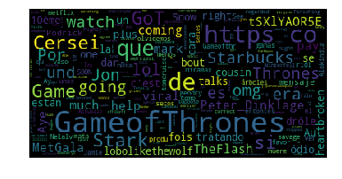

```python
!pip install wordcloud
from os import path
from wordcloud import WordCloud, STOPWORDS
import matplotlib.pyplot as plt
%matplotlib inline

text = str(dfo)

stopwords = set(STOPWORDS)
stopwords.add("https co")
stopwords.add("co")
stopwords.add("GameofThrones")

# Generate a word cloud image
wordcloud = WordCloud().generate(text)

# Display the generated image:
# the matplotlib way:
plt.imshow(wordcloud)
plt.axis("off")

# take relative word frequencies into account, lower max_font_size
wordcloud = WordCloud(max_font_size=40, relative_scaling=.5).generate(text)
plt.figure()
plt.imshow(wordcloud)
plt.axis("off")
```

## The first word in the text blob that sticks out is 'Starbucks' because a coffee cup was left on the table while filming!! We see that cersi is mentioned a lot, the Starks are being talked about a lot, and Jon's wolf.

# Twitter Storytelling:

## We analyzed twitter to get a feel for our are viewers are interacting, what they are sharing, who they are, what circles are they are in. It is hard to understand how a viewer likes the show from twitter because when game of thrones is on twitter it consists primarly of memes and jokes shared between thousands of people. Still we can understand that these accounts are advertising our show for us, at no cost to us. It is also good to see that our twitter account, as well as HBO's, is among the most popular when discussin Game of Thrones. Our network could be better connected. Our gephi map shows that there are many people not being involved or shared content but are still using the hashtag. Maybe this shows an opportunity for Game of thrones to create a promotion for interacting within the hastag. My main take away from twitter analysis is that Game of thrones is HUGE on twitter. So much so it gets flooded with low quality content and short conversations. If I were HBO and wanting to analyze the show I would not look towards twitter to analyze how our show is doing.

# Preparing our tweets for Network Analysis

```python
df = pd.read_csv("tweetdata.csv")
df.head()
```

|  | id | created at | text | screen name | followers_count | friends_count | name | lat | lon | place name | place type |
| --- | --- | --- | --- | --- | --- | --- | --- | --- | --- | --- | --- |
| 0 | 1125521393368670215 | Mon May 06 22:03:06 +0000 2019 | RT @sweetwinterchil: Rt if you think ghost was... | chaigeelatte2 | 71 | 389 | gee | NaN | NaN | NaN | NaN |
| 1 | 1125521393410629632 | Mon May 06 22:03:06 +0000 2019 | RT @kalopsiha: sansa: i won’t tell anyone \nar... | lowther_chryssy | 4 | 11 | Chrys | NaN | NaN | NaN | NaN |
| 2 | 1125521393695821824 | Mon May 06 22:03:06 +0000 2019 | RT @Glamorfonic: Ride a dragon one time and su... | bklynbrwlr | 717 | 694 | The Mirror Has Two Husbands | NaN | NaN | NaN | NaN |
| 3 | 1125521394211610624 | Mon May 06 22:03:06 +0000 2019 | RT @migueltheiii: @zane Fun Fact: Starbucks wa... | rhdian | 132 | 409 | راحديان | NaN | NaN | NaN | NaN |
| 4 | 1125521394845061121 | Mon May 06 22:03:06 +0000 2019 | RT @stima98: She finally let a man get close t... | aka_gunther | 1944 | 694 | DJ Voldebord 🧙🏽‍♂️ | NaN | NaN | NaN | NaN |

```python
df = df.drop(['followers_count', 'friends_count', 'lat', 'lon', 'place name', 'place type'],
            axis = 1)
```

```python
df.head()
```

|  | id | created at | text | screen name | name |
| --- | --- | --- | --- | --- | --- |
| 0 | 1125521393368670215 | Mon May 06 22:03:06 +0000 2019 | RT @sweetwinterchil: Rt if you think ghost was... | chaigeelatte2 | gee |
| 1 | 1125521393410629632 | Mon May 06 22:03:06 +0000 2019 | RT @kalopsiha: sansa: i won’t tell anyone \nar... | lowther_chryssy | Chrys |
| 2 | 1125521393695821824 | Mon May 06 22:03:06 +0000 2019 | RT @Glamorfonic: Ride a dragon one time and su... | bklynbrwlr | The Mirror Has Two Husbands |
| 3 | 1125521394211610624 | Mon May 06 22:03:06 +0000 2019 | RT @migueltheiii: @zane Fun Fact: Starbucks wa... | rhdian | راحديان |
| 4 | 1125521394845061121 | Mon May 06 22:03:06 +0000 2019 | RT @stima98: She finally let a man get close t... | aka_gunther | DJ Voldebord 🧙🏽‍♂️ |

```python
df = df[['created at', 'id', 'screen name', 'text', 'name']]
```

```python
df = df.head(1000)
len(df)
```

```
1000
```

```python
# let's process the data in list (better for text processing)

tweets = df.values
len(tweets)
```

```
1000
```

```python
for tweet in tweets[:2]:
    print(tweet)
```

```
['Mon May 06 22:03:06 +0000 2019' 1125521393368670215 'chaigeelatte2'
 "RT @sweetwinterchil: Rt if you think ghost was the best boy in winterfell and deserved all the pets jon didn't give him #GameOfThrones http…"
 'gee']
['Mon May 06 22:03:06 +0000 2019' 1125521393410629632 'lowther_chryssy'
 'RT @kalopsiha: sansa: i won’t tell anyone \narya: i won’t tell anyone \ntyrion: i won’t tell anyone \nvarys:\n#GameofThrones https://t.co/fzhwr…'
 'Chrys']
```

```python
for tweet in tweets[:5]:
    print(tweet[2], tweet[3])
```

```
chaigeelatte2 RT @sweetwinterchil: Rt if you think ghost was the best boy in winterfell and deserved all the pets jon didn't give him #GameOfThrones http…
lowther_chryssy RT @kalopsiha: sansa: i won’t tell anyone
arya: i won’t tell anyone
tyrion: i won’t tell anyone
varys:
#GameofThrones https://t.co/fzhwr…
bklynbrwlr RT @Glamorfonic: Ride a dragon one time and suddenly you forget about your Direwolf who’s literally saved your life.

Bastard. https://t.c…
rhdian RT @migueltheiii: @zane Fun Fact: Starbucks was originally called “Starkbucks” and was founded shortly before the Battle of Winterfell #Gam…
aka_gunther RT @stima98: She finally let a man get close to her and look what happens. Men are TRASH! #GameofThrones https://t.co/7TsEuhgVpu
```

```python
mention = []

for tweet in tweets:
    mention.append([tweet[2], tweet[3]])

mention[:5]
```

```
[['chaigeelatte2',
  "RT @sweetwinterchil: Rt if you think ghost was the best boy in winterfell and deserved all the pets jon didn't give him #GameOfThrones http…"],
 ['lowther_chryssy',
  'RT @kalopsiha: sansa: i won’t tell anyone \narya: i won’t tell anyone \ntyrion: i won’t tell anyone \nvarys:\n#GameofThrones https://t.co/fzhwr…'],
 ['bklynbrwlr',
  'RT @Glamorfonic: Ride a dragon one time and suddenly you forget about your Direwolf who’s literally saved your life. \n\nBastard. https://t.c…'],
 ['rhdian',
  'RT @migueltheiii: @zane Fun Fact: Starbucks was originally called “Starkbucks” and was founded shortly before the Battle of Winterfell #Gam…'],
 ['aka_gunther',
  'RT @stima98: She finally let a man get close to her and look what happens. Men are TRASH! #GameofThrones https://t.co/7TsEuhgVpu']]
```

```python
# computationally intensive ... very slow if you have a lot of data
for i in mention[:5]:
    print(i[0], i[1])
```

```
chaigeelatte2 RT @sweetwinterchil: Rt if you think ghost was the best boy in winterfell and deserved all the pets jon didn't give him #GameOfThrones http…
lowther_chryssy RT @kalopsiha: sansa: i won’t tell anyone
arya: i won’t tell anyone
tyrion: i won’t tell anyone
varys:
#GameofThrones https://t.co/fzhwr…
bklynbrwlr RT @Glamorfonic: Ride a dragon one time and suddenly you forget about your Direwolf who’s literally saved your life.

Bastard. https://t.c…
rhdian RT @migueltheiii: @zane Fun Fact: Starbucks was originally called “Starkbucks” and was founded shortly before the Battle of Winterfell #Gam…
aka_gunther RT @stima98: She finally let a man get close to her and look what happens. Men are TRASH! #GameofThrones https://t.co/7TsEuhgVpu
```

```python
for tweet in mention[:5]:
    print(tweet[0], re.findall(r"(?<=@)\w+", tweet[1]))
```

```
chaigeelatte2 ['sweetwinterchil']
lowther_chryssy ['kalopsiha']
bklynbrwlr ['Glamorfonic']
rhdian ['migueltheiii', 'zane']
aka_gunther ['stima98']
```

```python
for tweet in mention[:5]:
    a = re.findall(r"(?<=@)\w+", tweet[1])
    for i in a:
        print(tweet[0], i)
```

```
chaigeelatte2 sweetwinterchil
lowther_chryssy kalopsiha
bklynbrwlr Glamorfonic
rhdian migueltheiii
rhdian zane
aka_gunther stima98
```

```python
#putting everything together

import csv

mention = []
for tweet in tweets:
    mention.append([tweet[2], tweet[3]])

openfile = open("data/mentionnetwork.csv", "w", newline='')
w = csv.writer(openfile)

for tweet in mention:
    a = re.findall(r"(?<=@)\w+", tweet[1])
    for i in a:
        w.writerow([tweet[0], i])

openfile.close()
```

# Findings

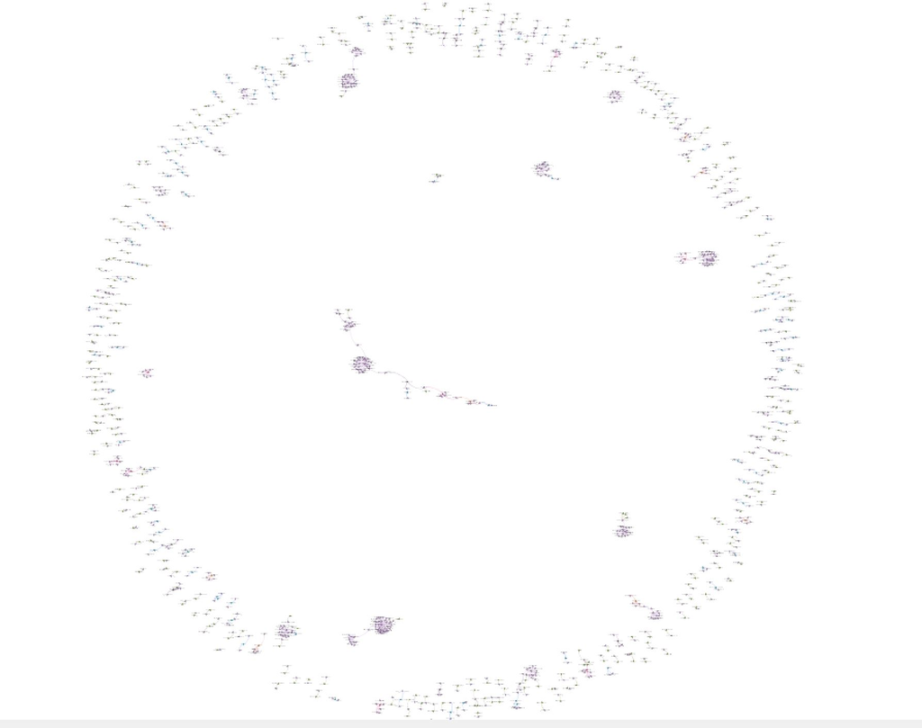

```python
from IPython.display import Image
Image("C:\\Users\\Grant\\Desktop\\670\\15_Final_Project\\big_network.JPG")
```

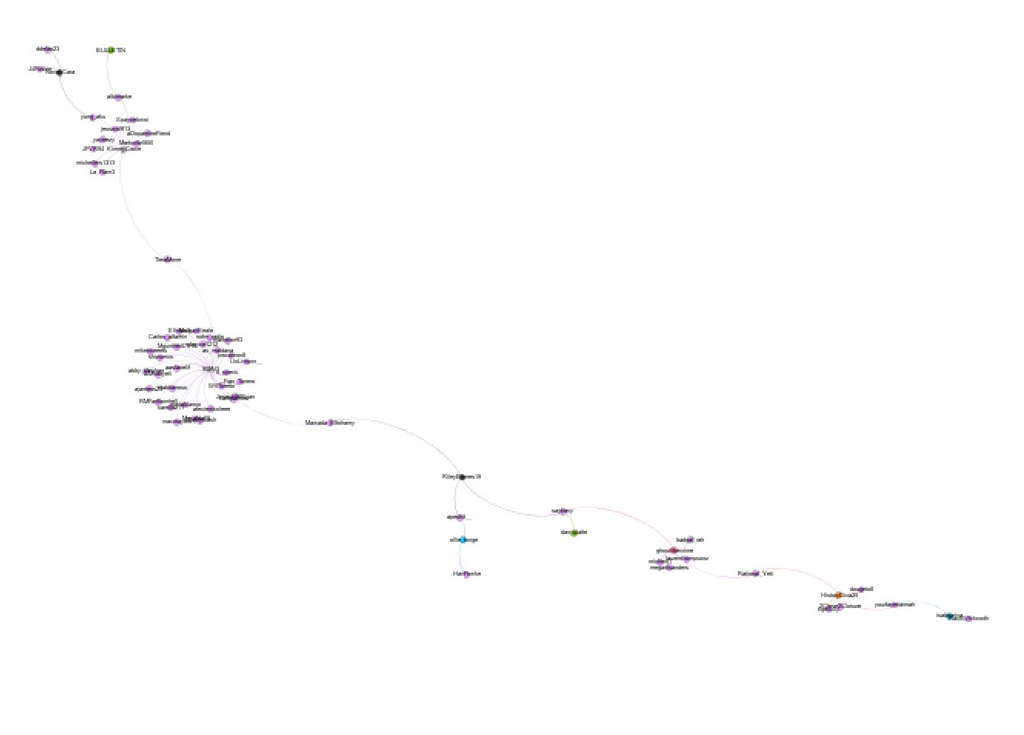

```python
from IPython.display import Image
Image("C:\\Users\\Grant\\Desktop\\670\\15_Final_Project\\small_network.JPG")
```